# Прогнозирование оттока клиентов

**Цель проекта**

Решение задачи классификации и обучения с учителем.

Построить модель, предсказывающую разрыв договора абонентом для осуществления борьбы с оттоком клиентов.

**Описание проекта**

Оператор связи «ТелеДом» хочет бороться с оттоком клиентов. Для этого его сотрудники начнут предлагать промокоды и специальные условия всем, кто планирует отказаться от услуг связи. Чтобы заранее находить таких пользователей, «ТелеДому» нужна модель, которая будет предсказывать, разорвёт ли абонент договор. Команда оператора собрала персональные данные о некоторых клиентах, информацию об их тарифах и услугах. Ваша задача — обучить на этих данных модель для прогноза оттока клиентов.

Заказчику важны:

- значение метрики качества ROC-AUC не меньше 0.85;
- интерпретируемость модели.

**Описание услуг**

Оператор предоставляет два основных типа услуг:

- Стационарную телефонную связь. Телефон можно подключить к нескольким линиям одновременно.
- Интернет. Подключение может быть двух типов: через телефонную линию (DSL, от англ. digital subscriber line — «цифровая абонентская линия») или оптоволоконный кабель (Fiber optic).

Также доступны такие услуги:

- Интернет-безопасность: антивирус (DeviceProtection) и блокировка небезопасных сайтов (OnlineSecurity);
- Выделенная линия технической поддержки (TechSupport);
- Облачное хранилище файлов для резервного копирования данных (OnlineBackup);
- Стриминговое телевидение (StreamingTV) и каталог фильмов (StreamingMovies).

Клиенты могут платить за услуги каждый месяц или заключить договор на 1–2 года. Возможно оплатить счёт разными способами, а также получить электронный чек.

**Описание данных**

Данные состоят из нескольких файлов, полученных из разных источников:

- `contract_new.csv` — информация о договоре;
- `personal_new.csv` — персональные данные клиента;
- `internet_new.csv` — информация об интернет-услугах;
- `phone_new.csv` — информация об услугах телефонии.

Файл `contract_new.csv`:

- `'customerID'` — идентификатор абонента;
- `'BeginDate'` — дата начала действия договора;
- `'EndDate'` — дата окончания действия договора;
- `'Type'` — тип оплаты: раз в год-два или ежемесячно;
- `'PaperlessBilling'` — электронный расчётный лист;
- `'PaymentMethod'` — тип платежа;
- `'MonthlyCharges'` — расходы за месяц;
- `'TotalCharges'` — общие расходы абонента.

Файл `personal_new.csv`:

- `'customerID'` — идентификатор пользователя;
- `'gender'` — пол;
- `'SeniorCitizen'` — является ли абонент пенсионером;
- `'Partner'` — есть ли у абонента супруг или супруга;
- `'Dependents'` — есть ли у абонента дети.

Файл `internet_new.csv`:

- `'customerID'` — идентификатор пользователя;
- `'InternetService'` — тип подключения;
- `'OnlineSecurity'` — блокировка опасных сайтов;
- `'OnlineBackup'` — облачное хранилище файлов для резервного копирования данных;
- `'DeviceProtection'` — антивирус;
- `'TechSupport'` — выделенная линия технической поддержки;
- `'StreamingTV'` — стриминговое телевидение;
- `'StreamingMovies'` — каталог фильмов.

Файл `phone_new.csv`:

- `'customerID'` — идентификатор пользователя;
- `'MultipleLines'` — подключение телефона к нескольким линиям одновременно.

Во всех файлах столбец `'customerID'` содержит код клиента. Информация о договорах актуальна на 1 февраля 2020 года.

Данные также находятся в тренажёре, в папке `/datasets/`.

**План работы**

**Шаг 1. Загрузка данных**

Загрузите данные и выполните их первичный осмотр.

**Шаг 2. Исследовательский анализ и предобработка данных**

Выполните исследовательский анализ каждого датафрейма и при необходимости выполните предобработку. Сделайте выводы об имеющихся признаках: понадобятся ли они для обучения моделей.

**Шаг 3. Объединение данных**

Объедините выбранные вами признаки в один датафрейм по ключу.

**Шаг 4. Исследовательский анализ и предобработка данных объединённого датафрейма**

Выполните исследовательский анализ объединённого датафрейма, визуализируйте распределения признаков и при необходимости выполните предобработку. Проведите корреляционный анализ. Напоминаем, что вы можете использовать не только имеющиеся признаки, но и генерировать новые.

**Шаг 5. Подготовка данных**

Выполните подготовку данных для обучения модели. Разделите данные на две выборки, при масштабировании и кодировании учитывайте особенности данных и моделей.

**Шаг 6. Обучение моделей машинного обучения**

Обучите как минимум две модели. Хотя бы для одной из них подберите как минимум два гиперпараметра.

**Шаг 7. Выбор лучшей модели**

Выберите лучшую модель и проверьте её качество на тестовой выборке.

**Шаг 8. Общий вывод и рекомендации заказчику**

Сделайте общий вывод о проделанной работе: опишите основные этапы работы, полученные результаты и дайте рекомендации для бизнеса.

# Содержание

## Загрузка данных

### Импорт библиотек

```python
# Обновление библиотеки sklearn
!pip install --upgrade scikit-learn -q
```

```python
import os
import re
import time

import matplotlib.pyplot as plt
import seaborn as sns
import pandas as pd
import numpy as np

from IPython.display import HTML
from tqdm.notebook import tqdm
from statsmodels.stats.outliers_influence import variance_inflation_factor

from sklearn.model_selection import (
    train_test_split,
    GridSearchCV,
    cross_val_score,
    cross_val_predict
)
from sklearn.preprocessing import (
    LabelEncoder,
    OneHotEncoder,
    StandardScaler,
    OrdinalEncoder
)
from sklearn.metrics import (
    roc_auc_score,
    roc_curve,
    accuracy_score,
    confusion_matrix,
    ConfusionMatrixDisplay
)
from sklearn.compose import ColumnTransformer
from sklearn.pipeline import Pipeline
from sklearn.linear_model import LogisticRegression
from sklearn.ensemble import RandomForestClassifier
from sklearn.dummy import DummyClassifier
from catboost import CatBoostClassifier
```

```python
!pip install phik -q
import phik
```

```python
# Отключаем ограничение по отображению колонок в таблице
pd.set_option('display.max_columns', None)
```

```python
# Фиксируем RANDOM_STATE
RS = 141024
```

### Создание функций

```python
# Функция для отображения списка только
# категориальных столбцов датафрейма.
def cat_col(dataset):
    return dataset.select_dtypes(exclude=['number', 'datetime64']).columns
```

```python
# Функция для отображения списка только
# количественных столбцов датафрейма.
def num_col(dataset):
    return dataset.select_dtypes(include=['number', 'datetime64']).columns
```

```python
# Функция для предварительного изучения
# общей информации о данных.
def data_research(dataset):
    # Отображение 5 первых и последних строк.
    display(dataset.head())
    display(dataset.tail())
    print()

    # Отображение информации о данных.
    display(HTML('<h3>Общая информация о данных</h3><br>'))
    print(dataset.info())

    # Отображение списка наименования столбцов.
    display(HTML('<h3>Наименования столбцов</h3><br>'))
    print(dataset.columns)

    # Проверка на пропуски и их изучение.
    display(HTML('<br><h3>Количество и доля пропущенных значений</h3><br>'))
    if dataset.isna().sum().any():
        display(HTML(
            f'<b>Количество пропусков во всем датафрейме: </b>'
            f'{dataset.isna().sum().sum()} '
            f'({round((dataset.isna().sum().sum() / (dataset.shape[0] * dataset.shape[1]) * 100), 1)}%)<br>'
        ))

        display(HTML(
            f'<b>Записи, имеющие хотя бы один пропуск: </b>'
            f'{dataset[dataset.columns].isna().any(axis=1).sum()} '
            f'({round((dataset[dataset.columns].isna().any(axis=1).sum() / dataset.shape[0] * 100), 1)}%)<br>'
        ))

        display(HTML('<b>Количество пропусков в каждом столбце: </b>'))
        display(pd.DataFrame({
            'count': dataset.isna().sum(),
            '%': dataset.isna().mean() * 100
        }).style.set_precision(1).background_gradient('YlGnBu'))
    else:
        print('Пропуски отсутствуют')

    # Проверка на явные дубликаты.
    display(HTML('<br><h3>Количество дубликатов в датафрейме</h3><br>'))
    if dataset.duplicated().sum() != 0:
        print(f'Всего: {dataset.duplicated().sum()} '
              f'({(dataset.duplicated().sum() / dataset.shape[0]):.2%} '
              f'от общего размера)')
    else:
        print('Явные дубликаты отсутствуют')

    # Проверка уникальных значений признаков.
    display(HTML('<br><h3>Уникальные значения в датафрейме</h3><br>'))
    for column in dataset.columns:
        display(HTML(
            f'<b>Уникальные значения в столбце "{column}": </b>'
            f'{len(dataset[column].unique())}'
        ))
        print(dataset.sort_values(by=column)[column].unique())
```

```python
# Функция построения графиков по всем признакам
def research_plot(dataset):
    # Если в датафрейме присутствуют количественные признаки.
    if len(num_col(dataset)) != 0:
        # Изучение информации о количественных данных.
        display(HTML('<br><h3>Описание количественных признаков</h3>'))
        display(dataset.describe(datetime_is_numeric=True))

        # Построение графиков для количественных данных.
        display(HTML('<br><h3>Графики для количественных признаков</h3><br>'))
        num_plots = len(num_col(dataset))
        # Рассчитываем количество строк.
        num_rows = (num_plots + 1) // 2 * 2
        # Создание фигуры и осей.
        fig, axes = plt.subplots(num_rows, 2, figsize=(14, 3 * num_rows))

        # Построение гистограмм и диаграмм размаха.
        for i, column in enumerate(num_col(dataset)):
            row = (i // 2) * 2
            col = i % 2

            # Гистограмма.
            sns.histplot(
                data=dataset,
                x=column,
                bins=20,
                kde=True,
                ax=axes[row, col]
            )
            axes[row, col].grid(True)
            axes[row, col].set_xlabel(column)
            axes[row, col].set_ylabel('Количество записей')
            axes[row, col].set_title(
                f'Распределение значений \n'
                f'и диаграмма размаха признака {column}'
            )

            # Диаграмма размаха.
            box_data = dataset[column]
            # Если тип данных признака - datetime64.
            if np.issubdtype(dataset[column].dtype, np.datetime64):
                # Если среди дат имеются пропуски.
                if box_data.isna().any():
                    # Удалим пропуски.
                    box_data = box_data.dropna()
                # Преобразуем признак в числовые значения.
                box_data = pd.DataFrame(pd.to_numeric(box_data))

            # Построение диаграммы размаха.
            sns.boxplot(
                data=box_data,
                orient='h',
                ax=axes[row + 1, col]
            )
            axes[row + 1, col].grid(True)
            axes[row + 1, col].set_xlabel(column)
            axes[row + 1, col].set_yticks([])

        # Скрытие последних пустых графиков,
        # если количество столбцов нечетное.
        if num_plots % 2 != 0:
            fig.delaxes(axes[-1, -1])
            fig.delaxes(axes[-2, -1])

        # Настройка макета.
        plt.tight_layout()
        plt.show()

    # Если в датафрейме присутствуют категориальные признаки.
    if len(cat_col(dataset)) != 0:
        # Построение графиков для категориальных данных.
        display(HTML('<br><h3>Графики для категориальных признаков</h3><br>'))
        # Убираем первый столбец с ID.
        for column in cat_col(dataset):
            # Отсортируем значения по убыванию частоты.
            sorted_counts = dataset[column].value_counts(ascending=True)
            # Создаем фигуру с двумя подграфиками.
            fig, axs = plt.subplots(1, 2, figsize=(15, 6))

            # Первый подграфик - столбчатая диаграмма.
            axs[0].barh(
                sorted_counts.index,
                sorted_counts.values,
                color=sns.color_palette('pastel')
            )
            axs[0].set_xlabel('Количество')
            axs[0].yaxis.set_tick_params(rotation=45)
            # Добавляем метки с числом упоминаний.
            for index, value in enumerate(sorted_counts.values):
                axs[0].text(value, index, str(value))

            # Второй подграфик - круговая диаграмма.
            axs[1].pie(
                sorted_counts.values,
                labels=sorted_counts.index,
                colors=sns.color_palette('pastel'),
                autopct='%1.1f%%'
            )
            plt.suptitle(
                f'Количество и доля уникальных значений столбца "{column}"'
            )
            plt.tight_layout()
            plt.show()
```

```python
# Функция для построения графиков для количественных признаков,
# разделенных на значения категориального признака.
def num_hue_plot(dataset, num_column, cat_column):
    # Создаем таблицу для сохранения описания данных.
    result = pd.DataFrame()
    # Добавляем описание данных по каждой категории.
    for i in dataset[cat_column].unique():
        # Получаем описание данных для текущей категории.
        desc = (
            dataset[dataset[cat_column] == i]
            [num_column].describe(datetime_is_numeric=True)
        )
        # Преобразуем результат в DataFrame и транспонируем его.
        desc_df = pd.DataFrame(desc).transpose()
        # Добавляем имя категории в качестве индекса.
        desc_df.index = [i]
        # Добавляем результат в общий DataFrame.
        result = pd.concat([result, desc_df])

    display(HTML(
        f'<br><h4>График распределения и диаграмма размаха значений признака '
        f'"{num_column}" с разделением по признаку "{cat_column}"</h4>'
    ))
    display(result)

    # Построение нормированной гистограммы
    plt.figure(figsize=(15, 6))
    sns.histplot(
        data=dataset,
        x=num_column,
        hue=cat_column,
        alpha=0.4,
        kde=True,
        bins=20,
        stat='density',
        common_norm=False
    )
    plt.grid(True)
    plt.xlabel('')
    plt.ylabel('Плотность распределения')
    plt.show()

    # Построение боксплота с уменьшенной высотой
    plt.figure(figsize=(15, 3))
    box_data = dataset[num_column]
    if np.issubdtype(dataset[num_column].dtype, np.datetime64):
        if box_data.isna().any():
            box_data = box_data.dropna()
        box_data = pd.to_numeric(box_data)
    sns.boxplot(data=dataset, x=box_data, y=cat_column)
    plt.grid(True)
    plt.show()
```

```python
# Функция для визуализации долей по уникальным значениям категориальных признаков.
def stacked_plot(dataset, features, target):
    # Создаем копию датасета, чтобы не изменять исходный
    dataset_copy = dataset.copy()

    # Кодируем целевой признак
    le = LabelEncoder()
    dataset_copy[target] = le.fit_transform(dataset_copy[target])

    # Вычисляем средний уровень оттока
    avg_churn_rate = dataset_copy[target].mean()
    num_plots = len(features)

    for i in range(0, num_plots, 2):
        fig, axs = plt.subplots(1, 2, figsize=(15, 5))
        for j in range(2):
            if i + j < num_plots:
                sns.barplot(
                    x=features[i + j],
                    y=target,
                    data=dataset_copy,
                    palette='pastel',
                    ax=axs[j]
                )
                axs[j].axhline(y=avg_churn_rate, color='red', linestyle='--')
                axs[j].xaxis.set_tick_params(rotation=90)
                axs[j].set_title(f'Средний уровень оттока '
                                 f'по "{features[i + j]}"')
                # Добавление подписей значений
                for p in axs[j].patches:
                    height = p.get_height()
                    axs[j].annotate(
                        f'{height:.1%}',
                        (p.get_x() + p.get_width() / 2, height / 2),
                        ha='center',
                        va='bottom'
                    )
        if num_plots % 2 != 0 and i + 1 == num_plots:
            fig.delaxes(axs[1])
        plt.tight_layout()
        plt.show()
```

```python
# Функция для расчета коэффициента инфляции дисперсии
def vif(dataset):
    display(HTML('<h3>Коэффициент инфляции дисперсии (VIF)</h3>'))
    vif_df = pd.DataFrame()
    vif_df['feature'] = dataset.columns
    vif_df['VIF'] = [
        variance_inflation_factor(dataset.values, i)
        for i in range(dataset.shape[1])
    ]
    display(vif_df.sort_values(by='VIF', ascending=False).style.background_gradient('YlGnBu'))
```

### Загрузка данных

Сохраняем в переменных названия файлов и возможные пути к ним.

```python
paths = [
    '/datasets/',
    r'C:\Users\oleg_\Downloads/'
]

files = [
    ('contract_data', 'contract_new.csv'),
    ('personal_data', 'personal_new.csv'),
    ('internet_data', 'internet_new.csv'),
    ('phone_data', 'phone_new.csv')
]
```

Загружаем данные из csv-файлов в датафрейм.

```python
for pth in paths:
    if os.path.exists(pth):
        for i, (data_name, file) in enumerate(files):
            if i == 0:
                globals()[data_name] = pd.read_csv(
                    os.path.join(pth, file),
                    decimal='.',
                    parse_dates=[1, 2]
                )
            else:
                globals()[data_name] = pd.read_csv(os.path.join(pth, file))
        break
else:
    print('Не удалось загрузить данные')
```

Сохраним все датафреймы в одной переменной для удобства обращения к ним в повторяющихся операциях.

```python
all_data = ['contract_data', 'personal_data',
            'internet_data', 'phone_data']
```

### Изучение общей информации

Изучим информацию при помощи функций `data_research` и `research_plot`.

Датафрейм `contract_data`

|  | customerID | BeginDate | EndDate | Type | PaperlessBilling | PaymentMethod | MonthlyCharges | TotalCharges |
| --- | --- | --- | --- | --- | --- | --- | --- | --- |
| 0 | 7590-VHVEG | 2020-01-01 | No | Month-to-month | Yes | Electronic check | 29.85 | 31.04 |
| 1 | 5575-GNVDE | 2017-04-01 | No | One year | No | Mailed check | 56.95 | 2071.84 |
| 2 | 3668-QPYBK | 2019-10-01 | No | Month-to-month | Yes | Mailed check | 53.85 | 226.17 |
| 3 | 7795-CFOCW | 2016-05-01 | No | One year | No | Bank transfer (automatic) | 42.30 | 1960.6 |
| 4 | 9237-HQITU | 2019-09-01 | No | Month-to-month | Yes | Electronic check | 70.70 | 353.5 |

|  | customerID | BeginDate | EndDate | Type | PaperlessBilling | PaymentMethod | MonthlyCharges | TotalCharges |
| --- | --- | --- | --- | --- | --- | --- | --- | --- |
| 7038 | 6840-RESVB | 2018-02-01 | No | One year | Yes | Mailed check | 84.80 | 2035.2 |
| 7039 | 2234-XADUH | 2014-02-01 | No | One year | Yes | Credit card (automatic) | 103.20 | 7430.4 |
| 7040 | 4801-JZAZL | 2019-03-01 | No | Month-to-month | Yes | Electronic check | 29.60 | 325.6 |
| 7041 | 8361-LTMKD | 2019-07-01 | No | Month-to-month | Yes | Mailed check | 74.40 | 520.8 |
| 7042 | 3186-AJIEK | 2014-08-01 | No | Two year | Yes | Bank transfer (automatic) | 105.65 | 7251.82 |

Общая информация о данных

```
<class 'pandas.core.frame.DataFrame'>
RangeIndex: 7043 entries, 0 to 7042
Data columns (total 8 columns):
 #   Column            Non-Null Count  Dtype
---  ------            --------------  -----
 0   customerID        7043 non-null   object
 1   BeginDate         7043 non-null   datetime64[ns]
 2   EndDate           7043 non-null   object
 3   Type              7043 non-null   object
 4   PaperlessBilling  7043 non-null   object
 5   PaymentMethod     7043 non-null   object
 6   MonthlyCharges    7043 non-null   float64
 7   TotalCharges      7043 non-null   object
dtypes: datetime64[ns](1), float64(1), object(6)
memory usage: 440.3+ KB
None
```

Наименования столбцов

```
Index(['customerID', 'BeginDate', 'EndDate', 'Type', 'PaperlessBilling',
       'PaymentMethod', 'MonthlyCharges', 'TotalCharges'],
      dtype='object')
```

Количество и доля пропущенных значений

```
Пропуски отсутствуют
```

Количество дубликатов в датафрейме

```
Явные дубликаты отсутствуют
```

Уникальные значения в датафрейме

**Уникальные значения в столбце "customerID":** 7043

```
['0002-ORFBO' '0003-MKNFE' '0004-TLHLJ' ... '9992-UJOEL' '9993-LHIEB'
 '9995-HOTOH']
```

**Уникальные значения в столбце "BeginDate":** 77

```
['2013-10-01T00:00:00.000000000' '2013-11-01T00:00:00.000000000'
 '2013-12-01T00:00:00.000000000' '2014-01-01T00:00:00.000000000'
 '2014-02-01T00:00:00.000000000' '2014-03-01T00:00:00.000000000'
 '2014-04-01T00:00:00.000000000' '2014-05-01T00:00:00.000000000'
 '2014-06-01T00:00:00.000000000' '2014-07-01T00:00:00.000000000'
 '2014-08-01T00:00:00.000000000' '2014-09-01T00:00:00.000000000'
 '2014-10-01T00:00:00.000000000' '2014-11-01T00:00:00.000000000'
 '2014-12-01T00:00:00.000000000' '2015-01-01T00:00:00.000000000'
 '2015-02-01T00:00:00.000000000' '2015-03-01T00:00:00.000000000'
 '2015-04-01T00:00:00.000000000' '2015-05-01T00:00:00.000000000'
 '2015-06-01T00:00:00.000000000' '2015-07-01T00:00:00.000000000'
 '2015-08-01T00:00:00.000000000' '2015-09-01T00:00:00.000000000'
 '2015-10-01T00:00:00.000000000' '2015-11-01T00:00:00.000000000'
 '2015-12-01T00:00:00.000000000' '2016-01-01T00:00:00.000000000'
 '2016-02-01T00:00:00.000000000' '2016-03-01T00:00:00.000000000'
 '2016-04-01T00:00:00.000000000' '2016-05-01T00:00:00.000000000'
 '2016-06-01T00:00:00.000000000' '2016-07-01T00:00:00.000000000'
 '2016-08-01T00:00:00.000000000' '2016-09-01T00:00:00.000000000'
 '2016-10-01T00:00:00.000000000' '2016-11-01T00:00:00.000000000'
 '2016-12-01T00:00:00.000000000' '2017-01-01T00:00:00.000000000'
 '2017-02-01T00:00:00.000000000' '2017-03-01T00:00:00.000000000'
 '2017-04-01T00:00:00.000000000' '2017-05-01T00:00:00.000000000'
 '2017-06-01T00:00:00.000000000' '2017-07-01T00:00:00.000000000'
 '2017-08-01T00:00:00.000000000' '2017-09-01T00:00:00.000000000'
 '2017-10-01T00:00:00.000000000' '2017-11-01T00:00:00.000000000'
 '2017-12-01T00:00:00.000000000' '2018-01-01T00:00:00.000000000'
 '2018-02-01T00:00:00.000000000' '2018-03-01T00:00:00.000000000'
 '2018-04-01T00:00:00.000000000' '2018-05-01T00:00:00.000000000'
 '2018-06-01T00:00:00.000000000' '2018-07-01T00:00:00.000000000'
 '2018-08-01T00:00:00.000000000' '2018-09-01T00:00:00.000000000'
 '2018-10-01T00:00:00.000000000' '2018-11-01T00:00:00.000000000'
 '2018-12-01T00:00:00.000000000' '2019-01-01T00:00:00.000000000'
 '2019-02-01T00:00:00.000000000' '2019-03-01T00:00:00.000000000'
 '2019-04-01T00:00:00.000000000' '2019-05-01T00:00:00.000000000'
 '2019-06-01T00:00:00.000000000' '2019-07-01T00:00:00.000000000'
 '2019-08-01T00:00:00.000000000' '2019-09-01T00:00:00.000000000'
 '2019-10-01T00:00:00.000000000' '2019-11-01T00:00:00.000000000'
 '2019-12-01T00:00:00.000000000' '2020-01-01T00:00:00.000000000'
 '2020-02-01T00:00:00.000000000']
```

**Уникальные значения в столбце "EndDate":** 67

```
['2014-06-01' '2014-09-01' '2014-10-01' '2014-11-01' '2014-12-01'
 '2015-01-01' '2015-02-01' '2015-03-01' '2015-04-01' '2015-05-01'
 '2015-06-01' '2015-07-01' '2015-08-01' '2015-09-01' '2015-10-01'
 '2015-11-01' '2015-12-01' '2016-01-01' '2016-02-01' '2016-03-01'
 '2016-04-01' '2016-05-01' '2016-06-01' '2016-07-01' '2016-08-01'
 '2016-09-01' '2016-10-01' '2016-11-01' '2016-12-01' '2017-01-01'
 '2017-02-01' '2017-03-01' '2017-04-01' '2017-05-01' '2017-06-01'
 '2017-07-01' '2017-08-01' '2017-09-01' '2017-10-01' '2017-11-01'
 '2017-12-01' '2018-01-01' '2018-02-01' '2018-03-01' '2018-04-01'
 '2018-05-01' '2018-06-01' '2018-07-01' '2018-08-01' '2018-09-01'
 '2018-10-01' '2018-11-01' '2018-12-01' '2019-01-01' '2019-02-01'
 '2019-03-01' '2019-04-01' '2019-05-01' '2019-06-01' '2019-07-01'
 '2019-08-01' '2019-09-01' '2019-10-01' '2019-11-01' '2019-12-01'
 '2020-01-01' 'No']
```

**Уникальные значения в столбце "Type":** 3

```
['Month-to-month' 'One year' 'Two year']
```

**Уникальные значения в столбце "PaperlessBilling":** 2

```
['No' 'Yes']
```

**Уникальные значения в столбце "PaymentMethod":** 4

```
['Bank transfer (automatic)' 'Credit card (automatic)' 'Electronic check'
 'Mailed check']
```

**Уникальные значения в столбце "MonthlyCharges":** 1585

```
[ 18.25  18.4   18.55 ... 118.6  118.65 118.75]
```

**Уникальные значения в столбце "TotalCharges":** 6658

```
[' ' '100.17' '100.19' ... '998.89' '999.6' '999.9']
```

Описание количественных признаков

|  | BeginDate | MonthlyCharges |
| --- | --- | --- |
| count | 7043 | 7043.000000 |
| mean | 2017-04-30 13:01:50.918642688 | 64.761692 |
| min | 2013-10-01 00:00:00 | 18.250000 |
| 25% | 2015-06-01 00:00:00 | 35.500000 |
| 50% | 2017-09-01 00:00:00 | 70.350000 |
| 75% | 2019-04-01 00:00:00 | 89.850000 |
| max | 2020-02-01 00:00:00 | 118.750000 |
| std | NaN | 30.090047 |

Графики для количественных признаков

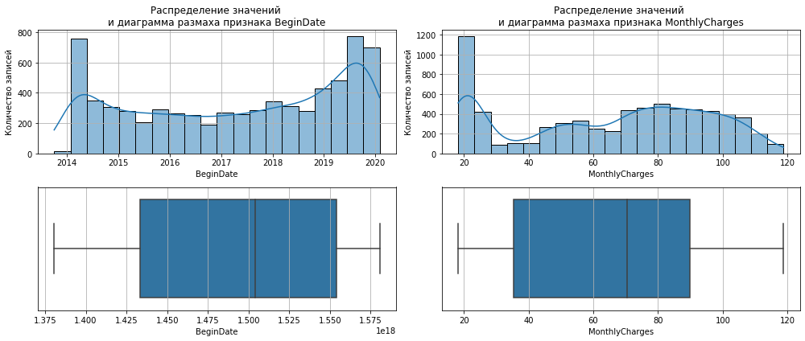

```python
display(HTML('<h1>Датафрейм `contract_data`</h1>'))

data_research(contract_data)

research_plot(contract_data[num_col(contract_data)])
```